# Knowledge Review: Tactical Data Preparation

Samuel Chan

2019-10-16

# 1 Overview

The materials covered in the following chapters can be used as standalone practice materials but are most effective when used as a knowledge review to supplement a more structured education.

The reason for that has everything to do about how we form knowledge. To cite the work of researchers from Berkeley Center for Teaching & Learning, where effective knowledge formation is concerned there are three basic stages: - Encoding: The process of forming new memories  
- Storage: The process of information maintenance  
- Retrieval: The process of gaining access to stored knowledge

This three-phase cycle is how learning takes place. The in-person lectures you receive allows your brain to take new information, and strategically execute round-trips between the encoding and storage functions. These lectures are typically high on information gain, but they don’t work your recall muscle too much. Well-planned lessons instead try to maximize connections by appealing to existing network of knowledge, and integrating new ideas into existing foundation.

The knowledge review serves a different role and designed to maximize your storage and recall In light of how the most robust memories are formed, it extends the trips between encoding and storage by incorporating added layers of retrieval. As you walk through the concepts and programming constructs, you’re reactivating the region of neurons to perform what is akin to a reconstruction process. Like body muscles, retrieval strengthens the storage process and making the memory itself more accessible in the future.

## 1.1 Prerequisites

This knowledge review can be used as standalone learning materials, but to get the best out of it, I recommend that you have: - Familiarity with dataframes (R’s `data.frame` or Pandas `DataFrame`)  
- Familiarity with subsetting operations  
- Familiarity with tabulation and aggregation functions

A recommended, but not required, resource is Algoritma’s [Programming For Data Science](https://algorit.ma/course/programming-data-science) course or its Python’s Python for Data Analytics specialization offered via it’s Academy.

## 1.2 Framework-flavored Versions

To keep this knowledge review accessible, it has to be somewhat “language-agnostic” and minimally opinionated. For this reason I have chosen to provide guidance code in base R and in `pandas`, but I’ll keep the use of any external libraries to an absolute minimal.

Readers of this material may choose to write code solutions using base R, the `tidyverse` alternatives (R), `pandas` (Python) or whichever packages they have the most familiarity in.

If you are using this knowledge review in an in-person workshop setting offered by Algoritma Data Science school or otherwise, feel free to work through the materials using the specific package(s) being taught in class. The takeaway of this knowledge review is not mastery of the code syntax – as that is the job of your instructors and your workshop assignments. The objective of this material is to instill a helpful mental model that can help you be more productive throughout your analysis, regardless of your programming language of choice.

# 2 Knowledge Review

## 2.1 Background

You have been hired into a book publishing company and on the first day on the job you are given a dataset (**data_input/books_c.csv**) and a list of questions regarding the most successful authors by the company’s business executives. To help you in this new role, we will go through an overview of the tactical approaches, by means of visual illustration and concrete examples.

You will learn how to approach an analysis, perform diagnosis and prepare the data for meaningful analysis. This sounds simple, so simple in fact that you may have observed professionals doing it instinctively in front of a live audience in the past. But herein lies the problem. Because professionals do it instinctively, beginners of data science are left with little to none in the way of a proper reference. To the beginner, so much of what happens from raw data to processed data, prime for analysis and modelling feels like a combination of gut instinct, prior knowledge, programming proficiency, and rapid troubleshooting.

While a professional navigate these different blocks of mental models swiftly and fluidly, a beginner in the audience is left searching for any semblance of structure. It’s one thing to learn the programming syntax of a language like Python or R. It’s a different thing to know how to solve problems efficiently and productively.

This knowledge review is not ambitious in its scope. It doesn’t aim to teach you everything about the syntax of a language. It tries only to develop a mental model – or a compass, or a blueprint – with which you can apply to make the data preparation a little more friendly to the beginner. It is not an adequate substitute for a programming book, or a programming course.

Let’s get started.

## 2.2 Short Feedback Cycle

Programming for data science is similar to programming in general. An important distinction is that much of data science work is done interactively, in an environment that encourages quick iteration and a short feedback loop. This usually takes the form of a notebook (Jupyter Notebook, R Markdown etc), where the user writes a few line of code at a time before sending these commands to the computer to be evaluated. Any values as a result of the execution is returned to the user.

This programming paradigm is great for data scientists and analysts because it allows the user to test an idea or a hypothesis in quick succession, with a tight feedback cycle. More and more, we see analysts and data scientists incorporating the ideas of interactive programming in their research process. Let’s begin with reading the dataset in.

You may recall doing it using R’s `read.csv()` command or `pandas` alternative (shown later). The `read.csv()` command has an additional `stringsAsFactors` parameter you can set that determine if the character strings are read as R’s factor types or left as-is. Recall that `factor` is just really a way of representing categorical data:

```r
books <- read.csv("data_input/books_c.csv", stringsAsFactors = FALSE)
print(books[1:6, 1:5])
```

| bookID | title | authors | average_rating | isbn |
| --- | --- | --- | --- | --- |
| 1 | Harry Potter and the Half-Blood Prince (Harry Potter #6) | J.K. Rowling | 4.56 | 0439785960 |
| 2 | Harry Potter and the Order of the Phoenix (Harry Potter #5) | J.K. Rowling | 4.49 | 0439358078 |
| 3 | Harry Potter and the Sorcerer’s Stone (Harry Potter #1) | J.K. Rowling | 4.47 | 0439554934 |
| 4 | Harry Potter and the Chamber of Secrets (Harry Potter #2) | J.K. Rowling | 4.41 | 0439554896 |
| 5 | Harry Potter and the Prisoner of Azkaban (Harry Potter #3) | J.K. Rowling | 4.55 | 043965548X |
| 8 | Harry Potter Boxed Set Books 1-5 (Harry Potter #1-5) | J.K. Rowling | 4.78 | 0439682584 |

Python developers will import the `pandas` library and use `.iloc` subsetting instead:

```python
import pandas as pd
books_py = pd.read_csv('data_input/books_c.csv')
books_py.iloc[:5, 1:5]
```

```
##                                                title  ...        isbn
## 0  Harry Potter and the Half-Blood Prince (Harry ...  ...  0439785960
## 1  Harry Potter and the Order of the Phoenix (Har...  ...  0439358078
## 2  Harry Potter and the Sorcerer's Stone (Harry P...  ...  0439554934
## 3  Harry Potter and the Chamber of Secrets (Harry...  ...  0439554896
## 4  Harry Potter and the Prisoner of Azkaban (Harr...  ...  043965548X
##
## [5 rows x 4 columns]
```

You just performed your first feedback loop. It was short (2 to 3 lines of code), and allow us to immediately evaluate the output of our code to see if it matches our expectations. Learning to write code that follows the short feedback cycle yields numerous advantages when you’re starting out. It allows on-the-fly course correction, and encourage the practice of decomposing a problem into smaller chunks (the ‘divide-and-conquer’ approach). Instead of expecting new programmers to compose a 500-line function that does something, this paradigm encourages writing 10 small pieces of code, each no more than 5 lines of code, to gradually and progressively inch towards the solution.

Of course, by not requiring the user to hold an unwieldy amount of information in their head, the reduced mental capacity give way to clarity and consequently, a less error-prone research.

I mention this so early on because getting into the habit of favoring short feedback cycle is foundational to many other concepts I’ll be presenting in this knowledge review.

Once you’ve read your dataset into your environment, you will inevitably have questions about the data. These questions may be based off your early assumptions about the data, or your first glance at a small subset of the data, and that is completely fine. What is *not fine* is to let these assumptions go unchecked. You probably wonder if the data has missing or incomplete values, if the rating is on a scale of 1 to 5, or what happens to the `authors` column when a book is co-authored by more than 3 authors.

If you’ve learned Programming for Data Science in either R or Python, these are example code blocks you may use. First some examples in R:

```r
summary(books[,c(4, 8:10)])
```

```
##  average_rating   X..num_pages    ratings_count     text_reviews_count
##  Min.   :0.000   Min.   :   0.0   Min.   :      0   Min.   :    0.0
##  1st Qu.:3.770   1st Qu.: 196.0   1st Qu.:     83   1st Qu.:    7.0
##  Median :3.960   Median : 301.0   Median :    630   Median :   40.0
##  Mean   :3.931   Mean   : 342.4   Mean   :  17765   Mean   :  533.6
##  3rd Qu.:4.130   3rd Qu.: 421.0   3rd Qu.:   4742   3rd Qu.:  222.0
##  Max.   :5.000   Max.   :6576.0   Max.   :5629932   Max.   :93619.0
```

```r
str(books)
```

```
## 'data.frame':    13714 obs. of  10 variables:
##  $ bookID            : int  1 2 3 4 5 8 9 10 12 13 ...
##  $ title             : chr  "Harry Potter and the Half-Blood Prince (Harry Potter  #6)" "Harry Potter and the Order of the Phoenix (Harry Potter  #5)" "Harry Potter and the Sorcerer's Stone (Harry Potter  #1)" "Harry Potter and the Chamber of Secrets (Harry Potter  #2)" ...
##  $ authors           : chr  "J.K. Rowling" "J.K. Rowling" "J.K. Rowling" "J.K. Rowling" ...
##  $ average_rating    : num  4.56 4.49 4.47 4.41 4.55 4.78 3.69 4.73 4.38 4.38 ...
##  $ isbn              : chr  "0439785960" "0439358078" "0439554934" "0439554896" ...
##  $ isbn13            : num  9.78e+12 9.78e+12 9.78e+12 9.78e+12 9.78e+12 ...
##  $ language_code     : chr  "eng" "eng" "eng" "eng" ...
##  $ X..num_pages      : int  652 870 320 352 435 2690 152 3342 815 815 ...
##  $ ratings_count     : int  1944099 1996446 5629932 6267 2149872 38872 18 27410 3602 240189 ...
##  $ text_reviews_count: int  26249 27613 70390 272 33964 154 1 820 258 3954 ...
```

And in `pandas`, `.describe()` will get you the statistical description:

```python
books_py.describe(include='int')
```

```
##              bookID        isbn13  ...  ratings_count  text_reviews_count
## count  13714.000000  1.371400e+04  ...   1.371400e+04        13714.000000
## mean   22159.859195  9.764017e+12  ...   1.776540e+04          533.632128
## std    13700.926816  3.987679e+11  ...   1.129572e+05         2529.006691
## min        1.000000  8.987060e+09  ...   0.000000e+00            0.000000
## 25%    10619.250000  9.780345e+12  ...   8.300000e+01            7.000000
## 50%    21321.500000  9.780613e+12  ...   6.305000e+02           40.000000
## 75%    33311.750000  9.780940e+12  ...   4.742250e+03          222.000000
## max    47709.000000  9.790008e+12  ...   5.629932e+06        93619.000000
##
## [8 rows x 5 columns]
```

Because of the short feedback loop, we spotted a few problems that worth further probing. Pay attention to the summary statistic for `X..num_pages` and `average_rating`. The minimum appears to be 0. This may or may not be a data entry error, but any books with a page of 0 is certainly worth inspecting closer.

Just for good measure, we may as well check for books with less than 5 pages.

This is your first quiz: If you have the answer, scroll down to the Quiz section and leave your answer below.

Quiz 1: How many books from our dataset have 5 or less pages? A. 174  
B. 157  
C. 147  
D. 13,557

```r
# Your R or Python code here
#
#
#
#
```

Take a closer look at these books. Use the ISBN provided to you to do a web search on these book titles and see if they are indeed a result of data entry error or are they consistent with your findings.

When you are done, take a moment to investigate the books with an `average_rating` of 0. Are they data entry errors or are these reasonable figures?

If you need some help, the following R code prints the book title and some helpful columns for your inspection for each book that has an average rating of 0:

```r
condition <- books$average_rating == 0
selected_cols <- c("title", "average_rating", "ratings_count", "text_reviews_count")
books[condition, selected_cols]
```

|  | title | average_rating | ratings_count | text_reviews_count |
| --- | --- | --- | --- | --- |
| 292 | Out to Eat London 2002 (Lonely Planet Out to Eat) | 0 | 0 | 0 |
| 425 | Juiced Official Strategy Guide | 0 | 0 | 0 |
| 1123 | Open City 6: The Only Woman He Ever Left | 0 | 0 | 0 |
| 2988 | How To Meditate: An Anthology Of Talks On Meditation And “Meditation: The Bridge Is Flowing But The River Is Not” | 0 | 0 | 0 |
| 3289 | Venac sonetnih venaca; Puževa srma | 0 | 0 | 0 |
| 4182 | Brodie’s notes on Aldous Huxley’s brave new world | 0 | 0 | 0 |

A `pandas` equivalent would be:

```python
condition = books_py.average_rating == 0
books_py.loc[condition, ['title', 'average_rating', 'ratings_count', 'text_reviews_count']].head()
```

```
##                                                   title  ...  text_reviews_count
## 291   Out to Eat London 2002 (Lonely Planet Out to Eat)  ...                   0
## 424                      Juiced Official Strategy Guide  ...                   0
## 1122           Open City 6: The Only Woman He Ever Left  ...                   0
## 2987  How To Meditate: An Anthology Of Talks On Medi...  ...                   0
## 3288                Venac sonetnih venaca; Puževa srma  ...                   0
##
## [5 rows x 4 columns]
```

Let’s walk through the steps we took again. We started by using a high-level “summary” function to obtain summary statistics of our data. When a business analyst working on processed – cleaned – dataset, these summary statistics are helpful in setting the tone for a business narrative (“story”).

But our data isn’t processed or cleaned yet. We are not interested in the summary statistics for its role in business insights, at least not at this stage. We are using `summary()` or `str()` because the compact overview of the data allow us to glean any quirks in our data.

> To glean is to gather ideas or information bit by bit. Glean originally meant to pick over a field after the harvest, now it means to gather anything, not just seeds and grains. When you glean information, you sort through ideas and take what you need

From what we gleaned, you notice the presence of non-sensical values (0 number of pages) and you learned that a few books with 0 ratings. You perform subsetting (sometimes referred to as “indexing”) to extract these observations for a closer inspection.

This series of action is sometimes affectionally called “sanity checks”. We perform sanity checks to get an idea of whether the data is in a state that conforms to our expectations. It is the precursor to more targeted diagnostic actions. As we write code to probe the data, we favor a problem-solving style that yields instantaneous feedback on tiny chunks at a time.

## 2.3 Two types of Questions

We have a preference in how we problem-solve: we want a **short feedback cycle**. Much like the same, we also have a preference in how we raise questions: we want **isolated contexts**.

Many beginners start a data science project by diving straight into the “insight extraction” business, deloying tools to retrieve statistics, produce aggregation tables and developing visualization. Diagnostic probes are thrown into the mix on an as-you-need basis.

I like to propose a model that I think is less burdensome to the beginner. Instead of one process, I’d teach beginners to approach them as if they were two distinct stages. The first phase is concerned with diagnosing the data to **identify any inconsistency** in the data and to **validate, or invalidate your assumptions** about the data. Your work in this stage is free from the burden of juggling insights extraction simultaneously.

What does invalidating your assumptions mean?

Assumptions are your opinions about the data based on current knowledge. After reading your dataset in and taking a peek at the first few rows, you may conciously or subconciously form “expectations” about the data. Try and retrieve a few rows of the `books` dataset again:

```r
# Your R or Python code here
#
#
#
#
```

You may be inclined to make some reasonable expectations from peeking at the first few rows of data:

- All books in this dataset have at least one or more review
- All books have a review score between 1 to 5
- All books have one author
- Any missing valus are encoded as `NA`

These are beliefs we form about the data, and what we think of as reasonable guesses prior to any investigative effort on the data. We then form questions that help us probe the dataset and guide our investigation to correct our misconceptions and re-adjust our understanding of the data. With practice this may seem more and more like an automatic mental reflex but it’s important to be aware of your assumptions and leave room for correction.

Robust Diagnostics questions serve to encourage any opportunities for correcting these assumptions.

The second phase deals with Exploratory questions, where the primary motive is pattern discovery and insights-driven. We’ll see examples of that in a later chapter.

To help you understand this process better, I’ve created a diagram that connect these ideas:

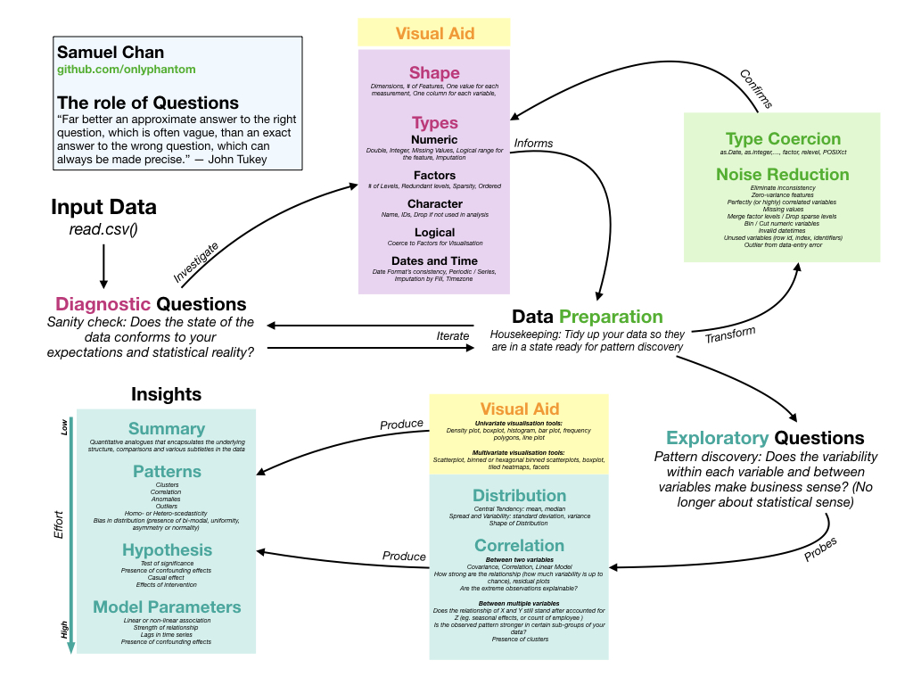

You can observe from the diagram the clear separation of contexts between Diagnostic Questions and Exploratory Questions. They are bridged by a drawn-out data preparation phase. It partitions the work of the practitioner so there is minimal “context switching” between troubleshooting and insight discovery.

When practitioners combine these phases in what they presume an Exploratory Data Analysis process looks like, it adds a lot of overhead to the beginner. For this reason I favor teaching a more rigid, stricter approach to data preparation to beginners. When we isolate the mental contexts, the practitioner tackles one kind of question at a time.

## 2.4 Diagnostics Questions

When forming Diagnostics Questions, you are concerned with the state of the data, not so much about the (business or otherwise) implications of your data. You want to form questions that allow you to contradict or disprove your prior assumptions; The key to forming good diagnostic questions is to be **definitive** and be conscious about your assumptions.

As you probe further into your data, your assumptions may change. New assumptions may form. After a few more probing, we picked up the following assumptions:

- You may be inclined to believe that the `bookID`, `isbn` and `isbn13` variables are redundant: they all act as an identifier for a unique product on Goodreads and the analyst is safe to pick either one of these 3
- You may be inclined to think that the `language_code` encodes “english” with `eng`, be it for British English or American English

Spend a few minutes on the above exercise, consciously noting all inclinations and add them to the list of questions below.

```r
# Your R or Python code here
#
#
#
#
```

Here are some diagnostic questions to get you started:

1. Are the `average_rating` on a scale of 1 to 5?
2. Do we have one, and only one, author for each value in `authors`?
3. Do we have missing values in the `authors` column?
4. Do we expect the value of `eng` for books written in English, regardless of the variation (American or British)?

Take some time to walk through each question and thoughtfully attempt to answer each of them. For question(1), you may be tempted to answer “yes” after a quick glance on the data, but if you perform a `range()` you would get a 0 and 5. Does that necessarily mean the rating scale is actually 0 to 5? Not so quick. The books that has a rating of 0 are books that have not received any reviews at all. Supposed we only look at the books that have been reviewed, at least once, it may contradict our earlier beliefs.

Run the code below and see if the output conforms with your prior assumptions:

```r
range(books[books$ratings_count > 0, "average_rating"])
```

And in `pandas`:

```python
books_nonzero = books_py.loc[books_py.ratings_count > 0, :]

[[books_py.average_rating.min(), books_py.average_rating.max()],
[books_nonzero.average_rating.min(), books_nonzero.average_rating.max()]]
```

```
## [[0.0, 5.0], [1.0, 5.0]]
```

I strongly urge you not to move on from this section until you’ve attempted the earlier questions.

### 2.4.1 Reference Answers

In this section I’ve included code snippets that you may find helpful for the earlier exercises. The code snippets are not in any particular order, and should be used as reference only. You may have to modify them – and I encourage you to – in your application to the questions above:

Find the book with the `average_rating`, and see if that is a result of the book having never been reviewed:

|  | title | average_rating | ratings_count |
| --- | --- | --- | --- |
| 12502 | Indian Action : An American Journey to the Great Fair of the East | 0 | 0 |
| 12956 | The Leadership Challenge: Skills for Taking Charge | 0 | 0 |
| 13084 | Anthony Thwaite: In Conversation With Peter Dale and Ian Hamilton | 0 | 0 |
| 13401 | Advances in Polymer Science Volume 194: Enzyme-Catalyzed Synthesis of Polymers | 0 | 0 |
| 13596 | Il genio e l’alienista: La strana visita di Lombroso a Tolstoj | 0 | 0 |
| 13646 | La habitacion oscura | 0 | 0 |

R developers may be familiar with the `which.max()` or `which.min()` functions. Take a second to look at the following code and see if you’re able to tell why this is not the right solution to the diagnostic question above:

```r
books[which.min(books$average_rating), c("title", "average_rating", "ratings_count")]
```

```r
ptable(books[which.min(books$average_rating), c("title", "average_rating", "ratings_count")])
```

|  | title | average_rating | ratings_count |
| --- | --- | --- | --- |
| 292 | Out to Eat London 2002 (Lonely Planet Out to Eat) | 0 | 0 |

For Python developers, your solution code may look like:

```python
books_py.loc[books_py.average_rating == books_py.average_rating.min(), ['title', 'average_rating', 'ratings_count']].head()
```

```
##                                                   title  ...  ratings_count
## 291   Out to Eat London 2002 (Lonely Planet Out to Eat)  ...              0
## 424                      Juiced Official Strategy Guide  ...              0
## 1122           Open City 6: The Only Woman He Ever Left  ...              0
## 2987  How To Meditate: An Anthology Of Talks On Medi...  ...              0
## 3288                Venac sonetnih venaca; Puževa srma  ...              0
##
## [5 rows x 3 columns]
```

Here is your second quiz: If you have the answer, scroll down to the Quiz section and leave your answer below.

Quiz 2: How many books have an average rating of 0 having been reviewed at least once? In other words, ignore the books that have not received any reviews yet and consider only books that have been reviewed. How many of these books have an average rating of 0? A. 1  
B. 4  
C. 5  
D. 0

```r
# Your R or Python code here
#
#
#
#
```

On the second diagnostic question (2. Do we have one, and only one, author for each value in `authors`?), a reference code solution is as follow:

```r
range(nchar(books$authors))
```

```
## [1]   3 772
```

The code retrieves the range (min and max) of the number of characters for values in the `authors` column. Does the min and max values conform to your earlier expectations regarding the data?

For `pandas`, your solution may look like:

```python
books_py.authors.str.len().describe()
```

```
## count    13714.000000
## mean        24.197171
## std         26.765088
## min          3.000000
## 25%         13.000000
## 50%         16.000000
## 75%         29.000000
## max        772.000000
## Name: authors, dtype: float64
```

You can additionally write code that inspect specific parts of the data that stood out as interesting to you. For example, following up from what we know about values in the `authors` column, we may want to retrieve the string that contains 772 characters: we have a basis to believe it could be a case of data entry error:

```r
maxchar <- which.max(sapply(books$authors, nchar))
books[maxchar, "authors"]
```

```
## [1] "Abigail Beckel-Kathleen Rooney-Chip Cheek-Amy L. Clark-Kirsten Culbertson-Mark Decarteret-Erin Dionne-Denise Duhamel-Elizabeth Kemper French-Lee    Harrington-Jen Heller-Chris Helmuth-Derrick Ableman-Steve Himmer-Brian Hinshaw-Jacqueline Holland-Amanda Holzer-Shannon Huffman-John F. Kersey-L…
```

You want to take note of how values are stored in the `authors` column.

If you probe further, you will notice that books with multiple authors are separated with a hyphen (`-`). You may also notice that popular work of literature that has been translated for different languages also appear as separate entries, each with its own `isbn` values. Names of the author of the original literature, as well as the translator are both recorded again in a hyphenated format:

|  | title | authors | language_code |
| --- | --- | --- | --- |
| 12661 | Harry Potter and the Philosopher’s Stone (Harry Potter #1) | J.K. Rowling | gla |
| 12662 | Гарри Поттер и философский камень (Harry Potter #1) | J.K. Rowling-Дж.К. Ролинг-И.В. Оранского | rus |
| 12663 | Harry Potter e il Calice di Fuoco | J.K. Rowling-Serena Daniele-Beatrice Masini-Serena Riglietti | ita |
| 13634 | Harry Potter und der Stein der Weisen (Harry Potter #1) | J.K. Rowling-Klaus Fritz | ger |
| 13638 | Harry Potter y el prisionero de Azkaban (Harry Potter #3) | J.K. Rowling | spa |
| 13639 | Harry Potter et le Prisonnier d’Azkaban (Harry Potter #3) | J.K. Rowling-Jean-François Ménard | fre |

For diagnostic questions relating to missing values in the `authors` column, there are built-in methods in R and `pandas` methods that may come in handy:

```python
books_py['authors'].isnull().sum()
```

```
## 0
```

R developers can instead use `anyNA` to check for the presence of missing values in the data:

```r
anyNA(books$authors)
```

```
## [1] FALSE
```

For the last diagnostic question above, we can look at all the possible values for the `language_code` column and see if they are consistent with your earlier hunch about the data:

```r
unique(books$language_code)[1:11]
```

```
##  [1] "eng"   "en-US" "spa"   "fre"   "en-GB" "mul"   "ger"   "ara"
##  [9] "por"   "grc"   "en-CA"
```

Your code in `pandas` may look something like that:

```python
books_py.language_code.value_counts()[:5]
```

```
## eng      10594
## en-US     1699
## spa        419
## en-GB      341
## ger        238
## Name: language_code, dtype: int64
```

As additional practice, write down two extra Diagnostic Questions:

- Diagnostic Question 1:
- Diagnostic Question 2:

Write your solution in pseudo-code or R / Python code below:

```r
# Your pseudo-code or solution code for Question 1
#
#
#
#
# Your pseudo-code or solution code for Question 2
#
#
#
#
```

Good solution code is one that is short, obvious, and provides an immediate feedback to the analyst. Try and adhere to these principles in your code solution above, and move on to the next chapter when you’re ready.

## 2.5 Data Preparation

Having identified any misconception about the data, you may also have discovered characteristics of the data that require special attention, or may even necessitate extra housekeeping. To give you some concrete examples of what data preparation may entail, I’ve modified the earlier diagram to emphasize on the preparatory steps:

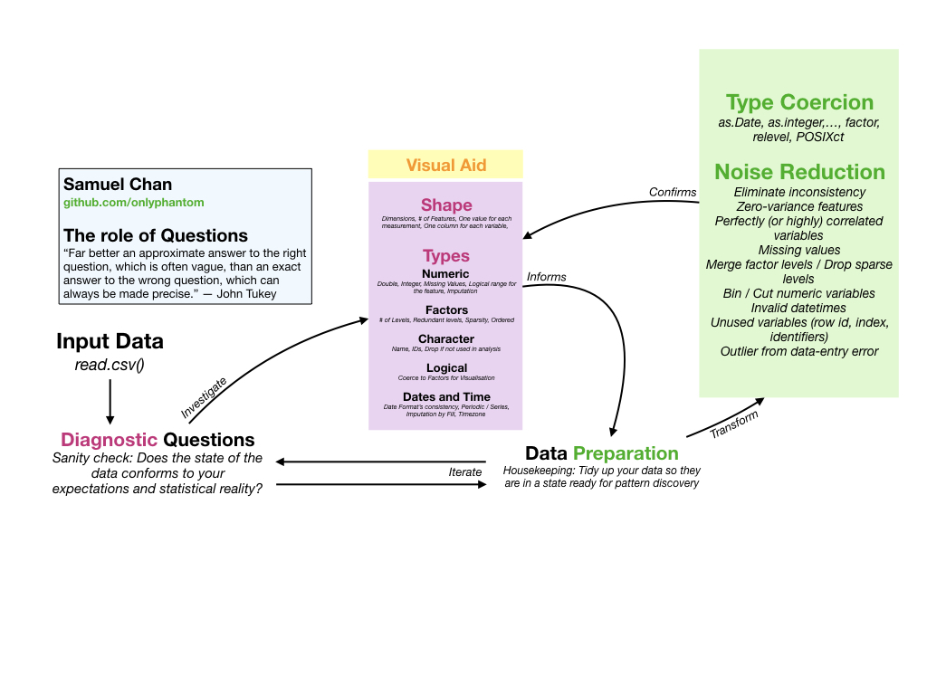

It may be obvious, but what’s worth mentioning is that the quality of your data preparation work is highly dependent on the level of thoroughness in the preceding, diagnostic phase. Any inconsistency or redundancy that requires correction are addressed in this phase.

### 2.5.1 Incorporate Prior Knowledge

Scientists and analysts often produce documentation or accompanying paper to describe the data collection process. Other times, you may have found the data from a public repository or source that includes a “README” describing how the data is collected. Even better, you may be put on a project where the data collection is handled within your team, yourself, or colleagues. Generally, data is collected either via manual entry or generated through a programmatic interface (API).

Having prior knowledge of how the data is collected can be advantageous in your data preparation phase.

When available, use these information to get a hunch about “how” or “why” inconsistencies in your data occur. I’ll give you some examples.

Supposed, during your investigation phase, you find that there is a missing value in the “author” column for one of the books. Given the prior knowledge that the data is manually filled out through a web form, a reasonable assumption would be that the data entry clark may have left the field empty because she did not have the available information at hand.

Supposed on the other hand that the database was populated via the Goodreads API (and not by hand, manually), you may have made different assumptions.

The prior knowledge that a web form being the medium of data entry may also increase the likelihood of a number of common data-entry related inconsistencies. A data entry clark may enter “JK. Rowling” while another may use “J.K. Rowling” and yet another may enter “Joanne Kathleen Rowling” or “J.k. Rowling”.

When you want to incorporate prior knowledge into a body of work meant to be consumed by others, feel free to use comments liberally (provided that they are helpful). On a project that uses `pandas`, say I have prior knowledge that the content management system automatically replace missing values with `---`, this can be handled early on during the `read_csv()` step by supplying custom values to the `na_values` parameter. To ensure that anyone reading the report have the same level of understanding, I can add comments to provide some background information that can help in understanding my code better:

```python
# CMS automatically append --- for any blank fields.
# Legacy system use n/a.
# Some fields contain 'not provided'. These need to be recognized as missing values
na_indicators = ['not provided', '---', 'n/a']
pd.read_csv('data_input/books_c.csv', na_values=na_indicators)
```

```r
# CMS automatically append --- for any blank fields.
# Legacy system use n/a.
# Some fields contain 'not provided'. These need to be recognized as missing values
read.csv("data_input/books_c.csv", na.strings = c("not provided", "---", "n/a"))
```

### 2.5.2 Incorporating Domain-specific Prior Knowledge

Consider datetimes, a common data type in many analysis. With prior knowledge, the analyst can often correctly encode these date times, determine timezones, extrapolate, or infer from it to figure out if a certain observation falls on a working day or not (Friday is not a working day in some countries and a working day in most others). The analyst can make reasonable guesses and assumptions on the peak traffic hours with prior knowledge of a city’s working hours. The analyst is able to draw correlations between observed values and his knowledge of the population’s sleeping habits and test these hypothesis. He is also more cautious, or sensitive, to the presence of causality when the effect of a certain intervention contradicts his prior knowledge of how, when and where the data is gathered.

Let’s expand on the “JK. Rowling” example earlier to illustrate this idea.

Building on the hunch of possible data entry inconsistency earlier, we can now form yet another Diagnostic Question: just how many variants of a name like “Rowling” are there (case-sensitive, punctuation points etc)?

Spend a minute to think of a solution and write your solution in pseudo-code or R / Python code below:

```r
# Your pseudo-code or solution code here
```

An example solution would be to find all strings containing `rowling` in the `authors` column using Regex (Regular Expression), ignoring case. If we find multiple variations of the same author, we can then perform further inspection:

```r
unique(books[grep("rowling", books$authors, ignore.case = TRUE), "authors"])
```

```
##  [1] "J.K. Rowling"
##  [2] "Lindsey Fraser-J.K. Rowling"
##  [3] "J.K. Rowling-J.K.羅琳-皇冠編譯組-張定綺-彭倩文-趙丕慧-林靜華"
##  [4] "J.K. Rowling-J.K.羅琳-彭倩文"
##  [5] "J.K. Rowling-Gemma Rovira Ortega"
##  [6] "J.K. Rowling-Peter Needham"
##  [7] "J.K. Rowling-Дж.К. Ролинг-Владимир Бабков-Виктор Голышев-Леонид Мотылев"
##  [8] "Newt Scamander-J.K. Rowling-Albus Dumbledore"
##  [9] "J.K. Rowling-Rufus Beck"
## [10] "J.K. Rowling-Sevin Okyay"
## [11] "J.K. Rowling-Дж.К. Ролинг-И.В. Оранского"
## [12] "J.K. Rowling-Serena Daniele-Beatrice Masini-Serena Riglietti"
## [13] "J.K. Rowling-Klaus Fritz"
## [14] "J.K. Rowling-Jean-François Ménard"
```

Or in `pandas`:

```python
cond = books_py.authors.str.contains('rowling', case=False)
[i for i in books_py.authors[cond].unique()]
```

```
## ['J.K. Rowling', 'Lindsey Fraser-J.K. Rowling', 'J.K. Rowling-J.K.羅琳-皇冠編譯組-張定綺-彭倩文-趙丕慧-林靜華', 'J.K. Rowling-J.K.羅琳-彭倩文', 'J.K. Rowling-Gemma Rovira Ortega', 'J.K. Rowling-Peter Needham', 'J.K. Rowling-Дж.К. Ролинг-Владимир Бабков-Виктор Голышев-Леонид Мотылев', 'Newt Scamander-J.K. Rowling-Albus D…
```

Understanding that J.K. Rowling’s Harry Potter series have been translated to numerous languages and follow the `[author]-[translator]` notation, we can modify our regex to print only the results where it ends with Rowling if we only wish to see a subset of that result:

```r
unique(books[grep("rowling$", books$authors, ignore.case = TRUE), "authors"])
```

```
## [1] "J.K. Rowling"                "Lindsey Fraser-J.K. Rowling"
```

In `pandas`:

```python
cond = books_py.authors.str.contains('rowling$', case=False)
[i for i in books_py.authors[cond].unique()]
```

```
## ['J.K. Rowling', 'Lindsey Fraser-J.K. Rowling']
```

We did not see the type of data entry inconsistency but if you’re an avid fiction / fantasy reader you may have noticed a different kind of peculiarity. Specifically, on the original list that was returned to us, we see a problematic inclusion in “Newt Scamander” and “Albus Dumbledore”.

|  | bookID | title | authors | average_rating | isbn | isbn13 | language_code | X..num_pages | ratings_count | text_reviews_count |
| --- | --- | --- | --- | --- | --- | --- | --- | --- | --- | --- |
| 12251 | 41899 | Fantastic Beasts and Where to Find Them | Newt Scamander-J.K. Rowling-Albus Dumbledore | 3.99 | 0439321603 | 9.780439e+12 | eng | 128 | 240268 | 5219 |

Newt Scamander and fellow Albus Dumbledore, as convincing as they may sound, are entirely fictional characters in the wizarding universe created by J.K. Rowling. Treating them as valid authors in our research may therefore lead to invalid statistics, or worse yet, misleading conclusions. This weirdly specific example can be generalized across multiple business domains. Having prior knowledge (or “domain knowledge”) can be very advantageous when these knowledge are deployed tactically in a data science or machine learning project.

In our example, an analyst familiar with the work of fiction authors would have correctly identified the fictional authors and perhaps correct them (i.e. replacing the fictional names with the real name of the actual author).

In a financial literature, an analyst familiar with the Indonesia Stock Exchange (IDX) may have spotted an inconsistency in one or more records when he noticed that a few stocks were trading outside the trading hours on a particular Friday. (Background: On Friday, trading hours for the Indonesia Stock Exchange is between 0900 to 1130 and then 1400 to 1600)

In a networking security domain, a private network analyst with existing knowledge of the company’s networking infrastructure may have spotted a few IP addresses that were not consistent with the address range inside a host.

These are only a handful of real-life examples where the application of prior knowledge can be a great asset in your data preparation toolkit.

### 2.5.3 Choosing a context between Exploratory or Modeling

Data preparation means different things depending on it’s intended role in the work you’re performing. A machine learning engineer prepares data such that the data is in a shape it needed to be in before being fed into a neural network. Outliers are removed because their presence are deemed “noise” and introduce unwanted variances or biases to the model. Categorical features are converted into numerics using techniques like one-hot encoding so the numeric representation can be fed into a machine learning algorithm. Character features, when they’re not categorical (first name, home address, email address etc) in nature, is neither useful to a classifier nor a regressor, leading them to be discarded early on in the data preparation phase as well.

A data scientist preparing the data for insights discovery and business intelligence operate differently. Character features such as name and email may prove to be useful for an analyst working on the customer retention team. Outliers are pointed out and studied, not discarded. Categorical features are not converted into numerical values but in a datatype that is more friendly for analysis. In R, that would be factors. In Python’s `pandas` ecosystem it would be the `Categorical` data type.

Sometimes, out of convenience, we are taught a pipeline that is overly linear:

Data Input -> Data Preparation -> Exploratory Data Analysis -> Machine Learning

This kind of simplification works for experienced practitioners. An experienced practitioner understood enough to connect the dots, relying on their experience to fill in the rest where necessary. But this attempt at simplification is detrimental to beginners because it sets the wrong expectations and – to the beginner – its simplicity added an appearance of correctness and appeal.

My advice is for you to pick and evaluate the context of your analysis. If it helps, tell yourself that you will be doing two sets of data preparation, resulting in two cleaned dataframes. A pre-exploratory data preparation where the outcome concerns insights discovery, and a pre-modelling data preparation with the goal of developing a good classifier or regressor.

### 2.5.4 Cautionary Modification and Understanding Copy

As a rule, you want to preserve a copy of the original dataframe, i.e. leaving it untouched. Any data cleansing and transformation tasks should be performed on a duplicated copy of the original dataset. Having the original dataframe “preserved” eliminates the need to read the data repeatedly into memory when you need to revert the changes you made. Reading data into memory can be a computationally expensive or time-consuming operation depending on the size of data and hardware specifications. If your data transmit over the internet (API endpoint, FTP or HTTP etc) the repeated “read” operation is wasteful, slow and may hit a limit in the case of an API service.

In a typical analysis project, you may also want to take the code you write – data transformation and other preparatory code – and roll them up into a script (.R or .py file). Supposed you take my advice and leave the original dataset unmodified, you can easily duplicate another copy of this original dataset to test your script on. You have an unmodified “baseline” to compare the results, and in the case of any discrepancy, you can just start all over from the baseline.

On the topic of duplicating data frames and leaving the original copy untouched, you need to have a working understanding of how each programming languages. Many beginner programmer think they already know how it works, but they may not. I’ll give you examples in R and Python.

In R, objects are copied by value but they are copied “lazily”. When you read in a dataset and a make a duplicated copy, the actual “copying” only happen when you make modifications on the new copy.

> In R semantics, objects are copied by value. This means that modifying the copy leaves the original object intact. Since copying data in memory is an expensive operation, copies in R are as lazy as possible. They only happen when the new object is actually modified.

```r
addr1 <- lobstr::obj_addr(books)
books_training <- books
addr2 <- lobstr::obj_addr(books_training)
books_training <- books_training[,-1]
addr3 <- lobstr::obj_addr(books_training)
list(addr1, addr2, addr3)
```

```
## [[1]]
## [1] "0x7f9d4f221a28"
##
## [[2]]
## [1] "0x7f9d4f221a28"
##
## [[3]]
## [1] "0x7f9d5052e5b8"
```

To “force” a duplicated copy, explicitly call `duplicate()` instead:

```r
x <- c(0,4,2)
addr1 <- lobstr::obj_addr(x)
y <- rlang::duplicate(x)
addr2 <- lobstr::obj_addr(y)
list(addr1, addr2)
```

```
## [[1]]
## [1] "0x7f9d51bc2ed8"
##
## [[2]]
## [1] "0x7f9d51b88e78"
```

In Python, can you guess what would be the outcome of `y` without executing the code?

```python
x = [0,4,2]
y = x
x.append(-3)

print(y)
```

If you execute the code above, does the output surprised you? The reason for that is that assignment statements (`=`) in Python do not copy objects, they only create bindings between a target and an object. When you modify the object, both bindings `x` and `y` point to the same modified object. The outcome of `print(y)` is `[0, 4, 2, -3]`.

Take a look at another example in Python below:

```python
x = [0,4,2]
y = x
y.append(-3)

print(x)
```

```
## [0, 4, 2, -3]
```

To actually make a copy in Python, use `.copy()` instead:

```python
x = [0,4,2]
y = x.copy()
x.append(-3)

print(y)
```

```
## [0, 4, 2]
```

These are admittedly more advanced concepts and probably not covered by most introductory data science workshops - however, having a general understanding of how common data analysis tasks differ across languages can save the analyst a lot of confusion in the long term. What may seem obvious in one language may be treated completely differently in another, as in the example above.

Quiz 3: What is the value of `x` after executing the following R code?

```r
x <- c(0,4,2)
y <- x
y <- c(y, -3)
```

A. A vector of 0, 4 and 2 B. A vector of 0, 4, 2 and -3 C. A vector of -3, 0, 4 and 2

As a final point on cautionary modification, assume you are handed down the following script from a team-mate, in which he performed some “tidying up” of the data, splitting the values in the `authors` column into multiple values spanning across multiple columns:

```r
library(dplyr)
books[grep("-", books$authors), ] %>%
  tidyr::separate(authors, into=c("main_author", "co_author", "co_author_2"), sep="-", fill="right") %>%
  head()
```

|  | bookID | title | main_author | co_author | co_author_2 | average_rating | isbn | isbn13 | language_code | X..num_pages | ratings_count | text_reviews_count |
| --- | --- | --- | --- | --- | --- | --- | --- | --- | --- | --- | --- | --- |
| 12 | 16 | The Hitchhiker’s Guide to the Galaxy (Hitchhiker’s Guide to the Galaxy #1) | Douglas Adams | Stephen Fry | NA | 4.22 | 0739322206 | 9.780739e+12 | eng | 6 | 1222 | 253 |
| 14 | 21 | A Short History of Nearly Everything | Bill Bryson | William Roberts | NA | 4.20 | 076790818X | 9.780768e+12 | eng | 544 | 228522 | 8840 |
| 27 | 35 | The Lord of the Rings (The Lord of the Rings #1-3) | J.R.R. Tolkien | Alan Lee | NA | 4.49 | 0618260587 | 9.780618e+12 | en-US | 1216 | 1606 | 139 |
| 28 | 36 | The Lord of the Rings: Weapons and Warfare | Chris Smith | Christopher Lee | Richard Taylor | 4.53 | 0618391002 | 9.780618e+12 | eng | 218 | 18934 | 43 |
| 31 | 40 | Cooking with Fernet Branca (Gerald Samper #1) | James Hamilton | Paterson | NA | 3.61 | 193337201X | 9.781933e+12 | eng | 288 | 1214 | 202 |
| 32 | 45 | Agile Web Development with Rails: A Pragmatic Guide | Dave Thomas | David Heinemeier Hansson | Leon Breedt | 3.89 | 097669400X | 9.780977e+12 | eng | 558 | 1269 | 59 |

As you inspect the code, your prior expertise in this domain alerted you to a potential problem. You notice that the use of a hyphen (`-`) as a separator between columns may lead to some false positives arising from hyphenated last name. One particular example would be the French writer Antoine de Saint-Exupéry. Upon closer inspection your suspicion is confirmed. Antoine’s hyphenated last name was incorrectly treated:

| bookID | title | main_author | co_author | co_author_2 | average_rating | isbn | isbn13 | language_code | X..num_pages | ratings_count | text_reviews_count |
| --- | --- | --- | --- | --- | --- | --- | --- | --- | --- | --- | --- |
| 8848 | Le Petit Prince | Antoine de Saint | Exupéry | NA | 4.3 | 2070513289 | 9.782071e+12 | fre | 123 | 348 | 19 |
| 28865 | Le Petit Prince | Antoine de Saint | Exupéry | NA | 4.3 | 0156013983 | 9.780156e+12 | fre | 87 | 2966 | 216 |
| 43246 | The Little Prince | Antoine de Saint | Exupéry | Katherine Woods | 4.3 | 0330239457 | 9.780330e+12 | eng | 96 | 50 | 5 |

Having preserved an unmodified copy, you can quickly verify your assumptions, perform the necessary correction, and have the “baseline” data to fall back on should there a need to revert these changes without having to re-acquire these data over an API:

```r
books[grep("Antoine", books$authors), ]
```

|  | bookID | title | authors | average_rating | isbn | isbn13 | language_code | X..num_pages | ratings_count | text_reviews_count |
| --- | --- | --- | --- | --- | --- | --- | --- | --- | --- | --- |
| 2867 | 8840 | Saint-Exupéry | Stacy Schiff-Antoine de Saint-Exupéry | 4.05 | 0805079130 | 9.780805e+12 | eng | 560 | 195 | 24 |
| 2868 | 8848 | Le Petit Prince | Antoine de Saint-Exupéry | 4.30 | 2070513289 | 9.782071e+12 | fre | 123 | 348 | 19 |
| 8991 | 28865 | Le Petit Prince | Antoine de Saint-Exupéry | 4.30 | 0156013983 | 9.780156e+12 | fre | 87 | 2966 | 216 |
| 12569 | 43246 | The Little Prince | Antoine de Saint-Exupéry-Katherine Woods | 4.30 | 0330239457 | 9.780330e+12 | eng | 96 | 50 | 5 |

# 3 Quiz

If you’ve made it this far, you may have completed 3 of out a total 5 quizzes. For the sake of completeness, the three questions are lifted directly from the body of knowledge review and included here.

Quiz 1: How many books from our dataset have 5 or less pages?

- [ ] A. 174
- [ ] B. 157
- [ ] C. 147
- [ ] D. 13,557

Quiz 2: How many books have an average rating of 0 having been reviewed at least once? In other words, ignore the books that have not received any reviews yet and consider only books that have been reviewed. How many of these books have an average rating of 0?

- [ ] A. 1
- [ ] B. 4
- [ ] C. 5
- [ ] D. 0

```r
x <- c(0,4,2)
y <- x
y <- c(y, -3)
```

Quiz 3: Based on the code chunk above, what is the value of `x`?

- [ ] A. A vector of 0, 4 and 2
- [ ] B. A vector of 0, 4, 2 and -3
- [ ] C. A vector of -3, 0, 4 and 2

Quiz 4: Read the dataset `books_c.csv` in and replace all variants of English (`eng`, `en-US`, `en-GB`, any other possible `en-__` variants) with `eng` in the `language_code` variable. How many books in the database are in English irrespective of its variants?

- [ ] A. 13714
- [ ] B. 12634
- [ ] C. 12643
- [ ] D. 12646

Quiz 5: What is a good example of a Diagnostic Question?

- [ ] A. “Does English books receive more ratings than books in other languages in general?”
- [ ] B. “Are there any books with a non-numeric ISBN value?”
- [ ] C. “What are the best-performing authors based on their reviews?”

# 4 Summary and Key Takeaways

1. Favor a problem-solving style that is efficient and yields a **short feedback cycle**
2. **Isolate contexts** by diagnosing your data before exploring it
3. **Diagnostic questions** are sanity checks. They asks: “does the state of data conform to my expectations and statistical reality?”
4. **Exploratory questions** are concerned with pattern discovery. They asks: “how can the information in the data be applied?”
5. Incorporate **prior knowkedge** and **domain knowledge** in your data preparation tasks
6. Preserve an **unmodified copy of the data** and understand that **every language behave differently** and yield different results even if they look semantically similar

# 5 Acknowledgements

1. Berkeley Center for Teaching & Learning | https://teaching.berkeley.edu
2. The books dataset used in the knowledge review section is provided by Soumek, courtesy of the Goodreads API and available on [Kaggle](https://www.kaggle.com/jealousleopard/goodreadsbooks). It is slightly modified to better fit the purpose of this content.